# Project title

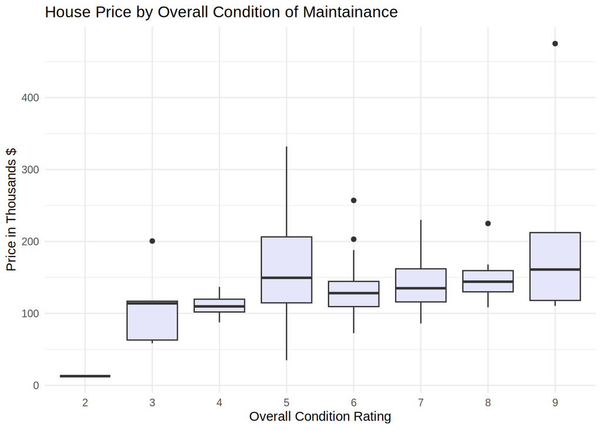

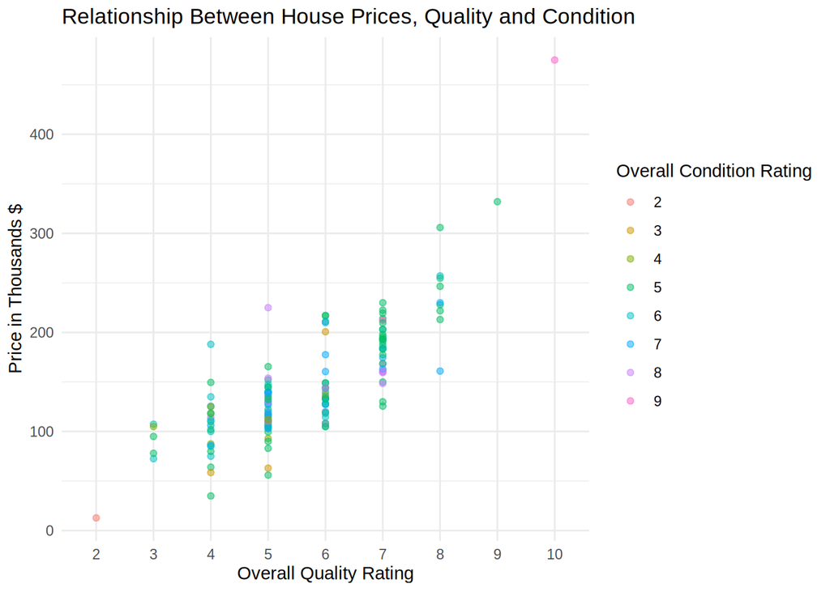

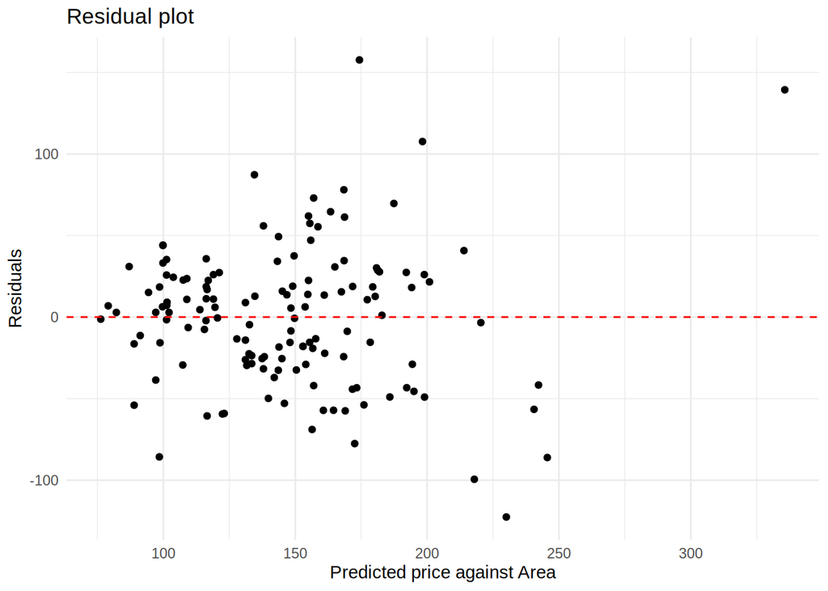

9. House Prices By quality by neighbourhood graph: A clear relationship is exemplified in this graph as two houses in the same neighbourhood of Old Town, with different ratings are sold for very different prices. However, the hypothesis can still be supported by the evidence within the medium ratings as Crawford and college creek continue to show higher prices than other neighbourhoods where houses had the same quality rating, yet this trend is less clear than the overall correlation between quality and price.

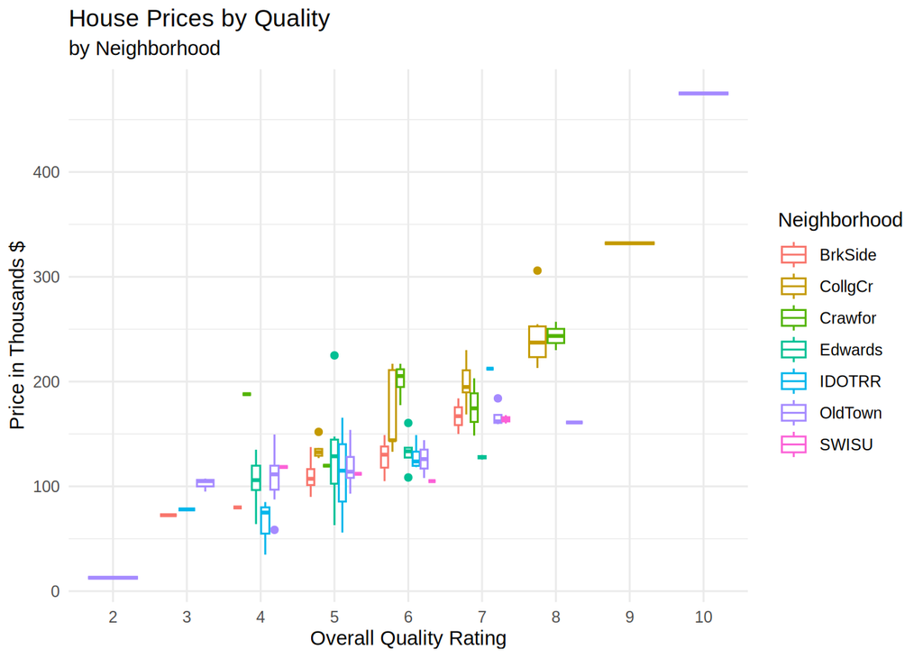

Linear regression model